# Updated: Visualizing Geospatial Data in R

Lauren Chan

2022-09-12

This is a tutorial to help you visualize spatial data in R. We will work with some preliminary Washington amphibian data. We can plot these points in Google Maps to get an idea of where in the world we are. Click this link to create a new map in your Google Maps account https://www.google.com/maps/d/mp?hl=en&authuser=0&state=create Import the WA_Sep7_pts.kml file.

## Before we get started

Before we get too far, make sure that you are in the directory with the files that you need access to. Remember that the Console is where you actually *are* and you can use the files tab to help you navigate there. Use `getwd()` and `dir()` to check that you are where you think you are!

### Make a new Rscript

Save it to your folder if you want to keep track of the code you’re writing and using!

# Visualizing Geospatial Data

This tutorial uses ggplot2 library.

# Load the libraries

```r
library(raster)
library(sp)
library(rgdal)
library(ggplot2)
```

# Load the Data

We have a couple different types of data.

A *raster* dataset is basically a two dimensional grid of data representing space. In each cell of the grid, there is a value and that value represents the data. It might represent elevation, or vegetation type, or presence or absence of some focal species. We will use raster datasets, but also will generate raster datasets later on.

We will also use a data table today, similar to what you would view in Excel or Google Sheets. In our case, we’ll use a simple text file without very much formatting so that R can read our data easily. Data tables can include all sorts of different information, like species, latitude and longitude, numbers or counts, ages, sizes, etc.

## 1. Load the Raster datasets

To load the raster, we simply use the `raster()` function and assign it to a variable. There are different raster files. Two types of data for two regions (North and South): *cover* for landcover and *dem* for Digital Elevation Model (aka Elevation). You don’t need to load them all. We will work with just the north_cover data for now.

```r
north_cover <- raster("cover_North.tif")
south_cover <- raster("cover_South.tif")
north_dem <- raster("dem_North.tif")
south_dem <- raster("dem_South.tif")
```

If we want to look at a raster we can click on the variable in the Environment panel (upper right), or simply just type the variable name.

```r
north_cover
```

```
## class      : RasterLayer
## dimensions : 938, 1273, 1194074  (nrow, ncol, ncell)
## resolution : 30, 30  (x, y)
## extent     : 430173.6, 468363.6, 5237704, 5265844  (xmin, xmax, ymin, ymax)
## crs        : +proj=utm +zone=10 +datum=NAD27 +units=m +no_defs
## source     : cover_North.tif
## names      : cover_North
## values     : 2, 25  (min, max)
```

As you can see, it is the datatype “RasterLayer” and it is an “object” meaning it has a bunch of parts to it - more complicated than a simple matrix. This dataset is 938 by 1273 cells and each cell is 30x30 meters (resolution).

## 2. Load the sampling localities

Our points file is a pretty simple file that is comma delimited (commas indicate values in different columns). It has GPS coordinates for each sample (latitude and longitude). We use `sep=","` to indicate that the comma is the separator between columns.

```r
pts <- read.delim("WAsamples_Sep7.txt", sep=",", strip.white=TRUE)
```

We can look at the first few rows using `head()`

```r
head(pts)
```

```
##    SampleID Latitude Longitude Species          Basin
## 1 Ch2020-94 46.50566 -123.3315   DIspp Upper Chehalis
## 2 Ch2020-99 46.50566 -123.3315    ASTR Upper Chehalis
## 3    WA0001 47.39048 -123.8010   DIspp     Humptulips
## 4    WA0002 47.39048 -123.8010   DIspp     Humptulips
## 5    WA0003 47.37264 -123.4839   DIspp         Satsop
## 6    WA0004 47.48061 -123.6193   DIspp     Humptulips
```

Take a look at the table above. What types of data are in each of the columns? Is this a matrix or a data.frame? Why?

## 3. Convert the point data from WGS84 (Lat/Long) to UTM

Our point data are in Lat/Long so we need to convert them. Simply paste the following three lines.

```r
coordinates(pts) <- c("Longitude", "Latitude")
projection(pts) <- CRS("+init=epsg:4326")
pts <- spTransform(pts, CRS("+proj=utm +zone=10"))
```

To more easily work with data, we convert transformed data from a SpatialPointsDataframe to a plain old data.frame.

```r
pts <- as.data.frame(pts)
names(pts) <- c("SampleID", "Species", "Basin", "x", "y")   # Rename columns
head(pts)
```

```
##    SampleID Species          Basin        x       y
## 1 Ch2020-94   DIspp Upper Chehalis 474567.9 5150286
## 2 Ch2020-99    ASTR Upper Chehalis 474567.9 5150286
## 3    WA0001   DIspp     Humptulips 439548.2 5248869
## 4    WA0002   DIspp     Humptulips 439548.2 5248869
## 5    WA0003   DIspp         Satsop 463468.0 5246690
## 6    WA0004   DIspp     Humptulips 453343.6 5258761
```

*Note: If you run into problems with any of these projections of the sample points, you will need to start over from the loading of the sample points text file.*

# Prepare the data for plotting

Now we have a few different rasters and some data.

## 1. Convert Raster data to a data.frame for ggplot2

In order to use ggplot2 to plot our raster data, we need to convert it to a data.frame. For each raster dataset, you can do the following set of steps. Note that you will need to call in the target raster dataset and use new variable names for the new datasets so you don’t overwrite others!

```r
# Example with DEM
# north_dem is name of original raster
ndem_pts <- rasterToPoints(north_dem, spatial = TRUE)
ndem_df  <- data.frame(ndem_pts)
names(ndem_df)   # Note that first column is called "dem_North"
```

```
## [1] "dem_North" "x"         "y"         "optional"
```

```r
# Example with LandCover
# north_cover is name of original raster
ncover_pts <- rasterToPoints(north_cover, spatial=TRUE)
ncover_df <- data.frame(ncover_pts)
names(ncover_df)   # Note that first column is called "cover_North"
```

```
## [1] "cover_North" "x"           "y"           "optional"
```

## 2. Split the pt data into north and south data

We have samples from two different clusters of sampling sites. We can sort them based on Basin. Right now, the only southern Basin is the Upper Chehalis

```r
npts <- pts[pts$Basin!="Upper Chehalis",]  # != is NOT equal
spts <- pts[pts$Basin=="Upper Chehalis",]  # == is equal
```

# Plot in ggplot2

## 1. Set up colors

If you know how to do this, and know what colors you want, and how many you need, jump to 1.2.3

### 1.1 Load some libraries

This is optional. You can use [default R base color palettes] (https://www.datanovia.com/en/blog/top-r-color-palettes-to-know-for-great-data-visualization/#r-base-color-palettes) if you choose.

There are loads and loads of color libraries. See here for info on [RColorBrewer](https://www.datanovia.com/en/blog/top-r-color-palettes-to-know-for-great-data-visualization/#rcolorbrewer-palettes), [ggsci](https://www.datanovia.com/en/blog/top-r-color-palettes-to-know-for-great-data-visualization/#scientific-journal-color-palettes), [wesanderson](https://www.datanovia.com/en/blog/top-r-color-palettes-to-know-for-great-data-visualization/#wes-anderson-color-palettes), and [pirate pal in the `yarrr` package](https://cran.r-project.org/web/packages/yarrr/vignettes/piratepal.html). Note: You may need to install the specific color package if you haven’t already.

```r
library(RColorBrewer)
library(ggsci)
library(wesanderson)
library(yarrr)
```

### 1.2 Set colors for the raster and for the data points

We will set two color palettes. One for the raster, `ras.color`, and one for the points `pt.color`. For the raster, if you are working with discrete data, you will need to know how many colors/values. If you are working with continuous data (e.g. DEM/elevation) you will need to decide how many bins or buckets. For point data, determine how many groups you have (how many different colors do you need). These will determine the length of your ras.color and pt.color vectors.

For the north landcover dataset, we can use `length(unique(ncover_df$cover_North))` to see how many distinct landcover types there are (19). For DEM, we’ll just pick 8 color bins.

For points, we have three species in the north and three species in the south (only one species of Rhyacotriton in each)

#### 1.2.1 Examples with raster palettes

Most palettes only have 5-12 colors. We need more in our case so we need to make them continuous, or add values between. See note below on how to do this.

```r
# The Wes Anderson palette lets you choose "continuous" or "discrete"
# so that you can do more than the 5 or 6 colors they provide.
ras.wes <- as.vector(wes_palette("FantasticFox1", n=19, type="continuous"))

# RBase palettes automatically add colors between
ras.base <- rainbow(19)

# ggsci, Rcolorbrewer, etc. typically have discrete palettes of a few colors.
# `pal_aaas()(10)` for example gives 10 discrete colors.
# We can use `colorRampPalette` and wrap around the pal_aaas()(10) to make more
# 19 in this case.
ras.ggsci <- colorRampPalette(pal_aaas()(10))(19)

ras.rcb <- colorRampPalette(brewer.pal(12, "Set3"))(19)

# Finally, if you want, you can set this manually as a vector of colors or hexcodes:
ras.mypal <- c("#466B9F","#D1DEF8","#DEC5C5","#D99282","#EB0000",
               "#AB0000","#B3AC9F","#68AB5F","#1C5F2C","#B5C58F",
               "#CCB879","#DFDFC2","#DCD939","#AB6C28","#B8D9EB",
               "#6C9FB8","#99d8c9","#2ca25f","#2c7fb8")
```

To Visualize any of these you can use a show_col() in the scales package (you’ll need to install first)

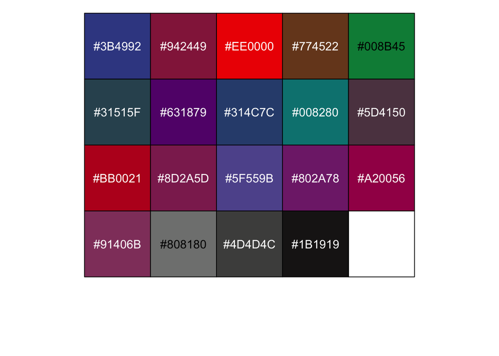

```r
library(scales) # will need to install
show_col(colorRampPalette(pal_aaas()(10))(19))
```

#### 1.2.2 Examples with palettes for points

Point palettes are a lot easier because there are only three categories. You can use a palette or set manually.

```r
pt.wes <- as.vector(wes_palette("Zissou1", n=3, type="discrete"))

pt.base <- rainbow(3)

pt.ggsci <- pal_simpsons()(3)
```

Use the same code to view:

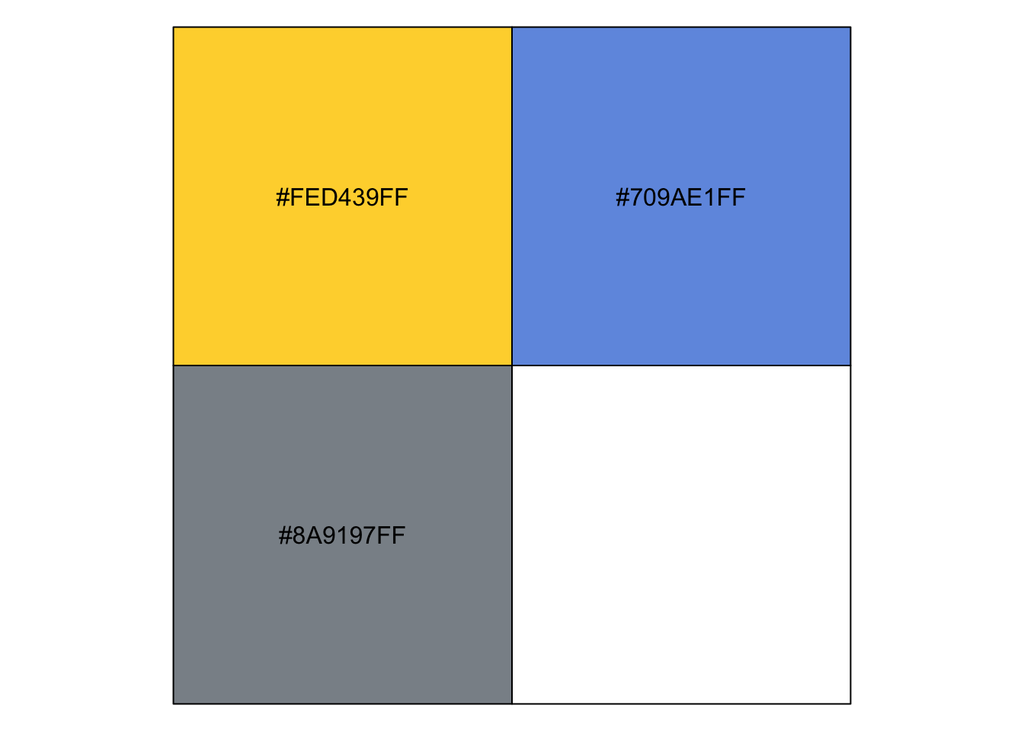

```r
show_col(pal_simpsons()(3))
```

#### **1.2.3 Set your actual color palettes**

For simplicity, call the one you use for the raster `ras.pal` and the one you set for the pts `pts.pal`

```r
ras.pal <- colorRampPalette(brewer.pal(12, "Set3"))(19)
pts.pal <- as.vector(piratepal(palette="xmen", length.out = 3))
```

## 2. Arrange legend (for discrete raster data)

For data like the landcover raster, the values are discrete and correpond to land cover types. We can set up a legend so that we can make sense of the map.

We load a “key”. There’s one for the North and one for the South. Look at it after you load it. Then you assign the column names of your raster palette to match the values in the key.

```r
key <- read.delim("NCover_Key.txt")
names(ras.pal) <- key$Value
```

## 3. Plot

With ggplot, we can store the plot to a variable and add components with the + sign. This first bit specifies the data. Then `geom_raster` plots the raster tell it that the x values are the x column, y is the y column and that the color of the cells should be determined by the value (in this case ‘cover_North’). We use “as.character” so that it is read as discrete, not continuous. We want to to look nice so we use `coord_equal()` to make cells square. Finally, `scale_fill_manual` colors the cells. It give the legend the title “Land Cover”, sets colors to our ras.pal. It sets the labels to the second column of key (? What is in that column??), and then has na.translate to deal with missing data.

```r
mymap <- ggplot(data=ncover_df) +
  geom_raster(aes(x=x, y=y, fill=as.character(cover_North))) +
  coord_equal() +
  scale_fill_manual(name="Land cover",
                    values=ras.pal,
                    labels=key[,2],
                    na.translate=F, )
```

** Nothing should plot yet. It’s stored in `mymap`

We add our points to the map. `geom_point` adds points. `scale_color_manual` sets the colors of the points and `scale_shape_manual` sets their shape (see [this resource](http://www.sthda.com/english/wiki/r-plot-pch-symbols-the-different-point-shapes-available-in-r)). The annotate lines write text and line seqments, respectively and place it on the figure with x and y coordinates.

```r
mymap <- mymap +
  geom_point(data=npts, aes(x=x, y=y, color=Species, shape=Species)) +
  #geom_jitter(data=npts, aes(x=x, y=y, color=Species, shape=Species), width=300, height=300) +
  scale_color_manual(values=pts.pal) +
  scale_shape_manual(values=c(15,16,18)) +
  annotate("text", x = 436000, y = 5241500, label = "10 kms") +
  annotate("segment", x=431000, xend=441000, y=5240000, yend=5240000,
           color="black", size=2)
```

See how it looks. Type `mymap`.

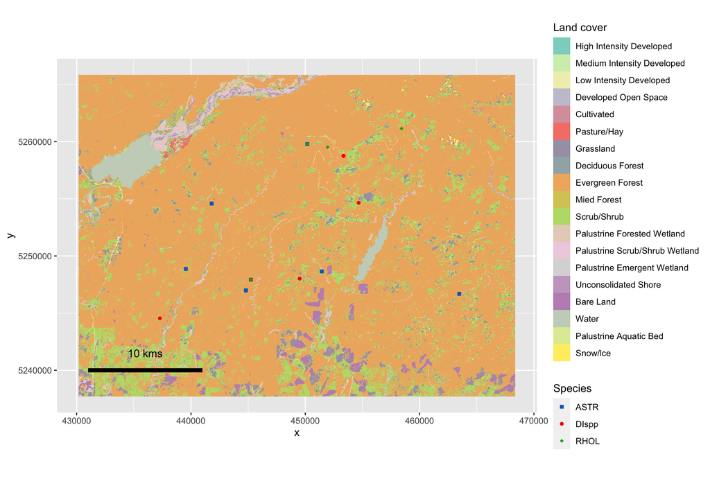

```r
mymap
```

## Things to do:

- Change colors!
- Points overlap! Replace the geom_point line with the geom_jitter line (just uncomment!). jittering moves points randomly some bit, set by width and height. Mess with width and height and see how points change.
- Change the point shapes and colors!

An example. I can put all in one block if I want (what did I need to do?)

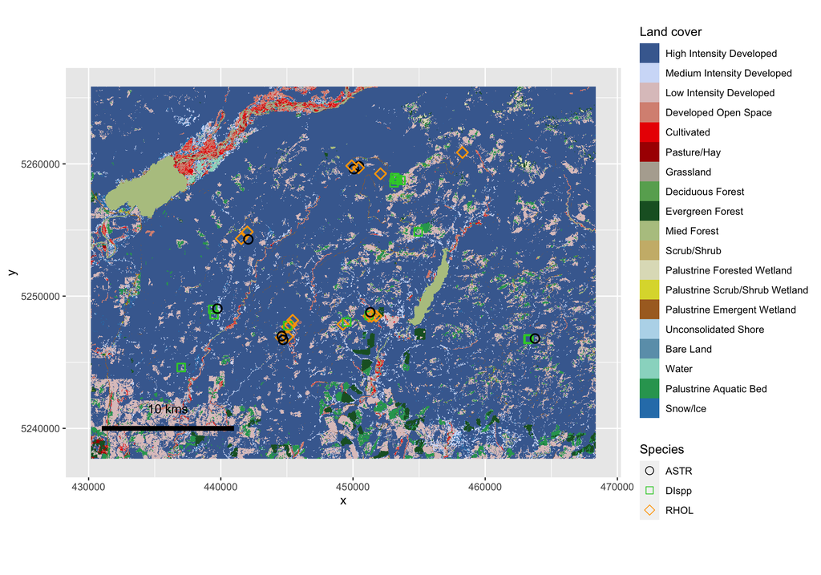

```r
ras.pal <- ras.mypal
pts.pal <- c("black", "limegreen", "orange")

mymap <- ggplot(data=ncover_df) +
  geom_raster(aes(x=x, y=y, fill=as.character(cover_North))) +
  coord_equal() +
  scale_fill_manual(name="Land cover", values=ras.pal, labels=key[,2], na.translate=F) +
  #geom_point(data=npts, aes(x=x, y=y, color=Species, shape=Species)) +
  geom_jitter(data=npts, aes(x=x, y=y, color=Species, shape=Species, stroke=1), cex=3, width=300, height=300) +
  scale_color_manual(values=pts.pal) +
  scale_shape_manual(values=c(21,22,23)) +
  annotate("text", x = 436000, y = 5241500, label = "10 kms") +
  annotate("segment", x=431000, xend=441000, y=5240000, yend=5240000,
           color="black", size=2)
mymap
```